# BTL-DataVisualization

2025-11-06

```r
StudentsPerformance <- read.csv("C:/Users/ASUS/Downloads/New_data.csv")
```

```r
library(ggplot2)
library(plotly)
library(shiny)
library(tidyverse)
library(RColorBrewer)
```

Trong phần này, dữ liệu được trực quan hóa thông qua các biểu đồ Histogram và Boxplot nhằm mô tả đặc điểm phân bố điểm số của học sinh, cũng như đánh giá sự khác biệt giữa các nhóm nhân khẩu học và điều kiện học tập. Việc trình bày dữ liệu bằng đồ thị giúp quan sát xu hướng tổng quát, phát hiện các giá trị ngoại lai và hiểu rõ mức độ biến thiên của từng biến trong bộ dữ liệu.  
**1. Trực quan hóa bằng đồ thị Histogram.**  
*Khởi tạo đồ thị histogram sử dụng thư viện ggplot2*

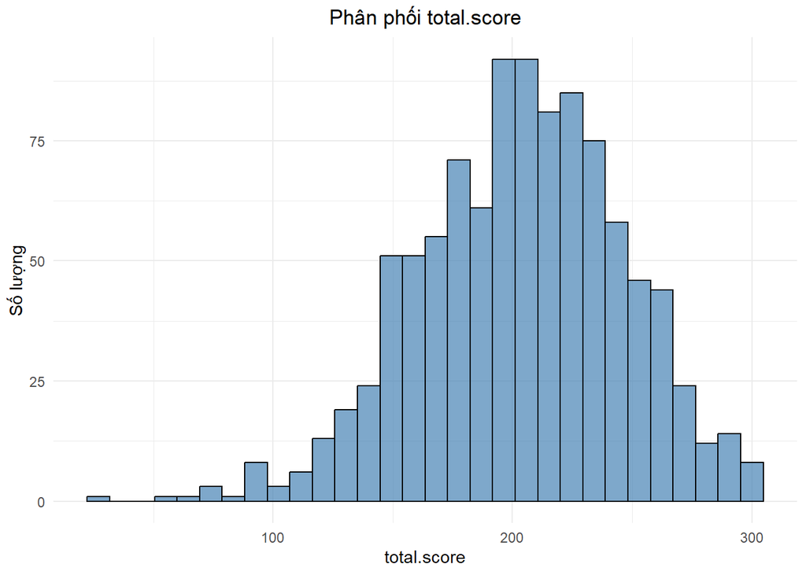

```r
ggplot(StudentsPerformance, aes(x = total.score)) +
  geom_histogram(fill = "steelblue", color = "black",alpha = 0.7) +
  labs(title = "Phân phối total.score",
       x = "total.score",
       y = "Số lượng") +
  theme_minimal()+
    theme(plot.title = element_text(hjust = 0.5))
```

Đồ thị Histogram trên mô tả phân bố *total.score* của 1000 học sinh trong tập dữ liệu. Quan sát đồ thị cho thấy:

- Dữ liệu tập trung nhiều nhất ở vùng từ khoảng 180 đến 240 điểm .Đây là vùng có tần suất xuất hiện cao nhất, tạo thành phần đỉnh chuông rõ rệt.
- Dải điểm từ 0 đến 100 hiếm gặp, chỉ có vài học sinh đạt mức này .Điều này tạo nên phần đuôi hơi lệch trái.
- Một số học sinh đạt tổng điểm rất cao (trên 280 điểm), nhưng số lượng không nhiều.
- Tổng điểm trải dài từ khoảng 20 đến 300, cho thấy sự khác biệt đáng kể về năng lực học sinh.

**2.Trực quan hóa bằng Bar chart.**

[interactive chart not shown]

**Nhận xét:**  
Đồ thị phân bố theo gender:

- Tỷ lệ học sinh nữ (518) cao hơn học sinh nam (482), nhưng chênh lệch không đáng kể.
- Điều này cho thấy dataset khá cân bằng về giới tính, không bị lệch mạnh sang một phía.
- Vì hai nhóm gần tương đương, việc so sánh điểm số theo giới sau này sẽ khách quan và không bị sai lệch do khác biệt lớn về kích thước mẫu.

Đồ thị phân bố theo race.ethnicity:

- Nhóm group C có số lượng học sinh nhiều nhất (319).
- Nhóm group D và group B ở mức trung bình.
- Nhóm group A và group E ít hơn đáng kể, đặc biệt group A (89).
- Dataset hơi lệch về một số nhóm chủng tộc, do đó khi so sánh điểm theo race.ethnicity, cần xem xét khả năng mất cân bằng mẫu giữa các nhóm.

Đồ thị phân bố theo parental.level.of.education:

- Trình độ học vấn của cha mẹ phân bố không đều.
- Các nhóm some college, associate’s degree, và high school chiếm tỷ lệ lớn nhất.
- Nhóm master’s degree có số lượng ít nhất (59).
- Điều này phản ánh sự đa dạng trong nền tảng học vấn gia đình, nhưng cũng cho thấy các nhóm trình độ cao có cỡ mẫu nhỏ, cần thận trọng khi diễn giải.

Đồ thị phân bố theo lunch:

- Học sinh dùng standard lunch chiếm đa số (645).
- Nhóm free/reduced lunch ít hơn khá rõ (355).
- Điều này phản ánh: dataset có tỷ lệ học sinh kinh tế khó khăn thấp hơn.
- Khi phân tích điểm total.score theo lunch, cần lưu ý sự không cân bằng mẫu này.

Đồ thị phân bố theo test.preparation.course:

- Phần lớn học sinh không tham gia khóa chuẩn bị thi (642).
- Chỉ có 358 học sinh đã completed khóa học.
- Điều này cho thấy đa số học sinh không nhận hỗ trợ/hướng dẫn trước kỳ thi,việc so sánh điểm của nhóm completed với none có thể cho thấy ảnh hưởng thực tế của việc luyện thi.

Tổng thể, các biểu đồ cho thấy dữ liệu cân đối ở biến gender nhưng có sự chênh lệch ở các biến race.ethnicity, parental.level.of.education, lunch và test.preparation.course; vì vậy khi phân tích total.score theo các biến này, cần lưu ý đến sự không đồng đều về kích thước mẫu giữa các nhóm để đảm bảo nhận định được khách quan và chính xác.

**3.Trực quan hóa bằng đồ thị Boxplot.**  
*Khởi tạo lần lượt 5 đồ thị Boxplot sử dụng thư viện ggplot2*

```r
graph1 <- ggplot(
StudentsPerformance, aes(x=gender, y=total.score , fill=gender))+
geom_boxplot()+
labs(title= "Ảnh hưởng của gender lên total.score",x="gender",y="total.score")+
scale_fill_brewer(palette = "Set2")+ #đổi màu biểu đồ
theme(legend.position="none", plot.title = element_text(hjust = 0.5, size = 13)
      )
graph2 <- ggplot(
StudentsPerformance, aes(x=race.ethnicity, y=total.score, fill=race.ethnicity))+
geom_boxplot()+
labs(title="Ảnh hưởng của race.ethnicity lên total.score",x="race.ethnicity",y="total.score")+
scale_fill_brewer(palette="Pastel1")+
theme(legend.position="none", plot.title = element_text(hjust = 0.5, size = 13)
      )
graph3 <- ggplot(
StudentsPerformance, aes(x=parental.level.of.education, y=total.score, fill=parental.level.of.education)) +
geom_boxplot()+
labs(title= "Ảnh hưởng của parental.level.of.education lên total.score",x="parental.level.of.education  ",y="total.score") + scale_fill_brewer(palette = "PiYG")+
theme(legend.position="none", plot.title = element_text(hjust = 0.5, size = 13)
      )
graph4 <- ggplot(
StudentsPerformance, aes(x=lunch, y=total.score, fill=lunch)) +
geom_boxplot()+
labs(title= "Ảnh hưởng của lunch lên total.score",
x="lunch",y="total.score") + scale_fill_brewer(palette = "Paired")+
theme(legend.position="none", plot.title = element_text(hjust = 0.5, size = 13)
      )
graph5 <- ggplot(
StudentsPerformance, aes(x=test.preparation.course, y=total.score, fill=test.preparation.course)) +
geom_boxplot()+
labs(title= "Ảnh hưởng của test.preparation.course\n lên total.score",
x="test.preparation.course",y="total.score") + scale_fill_brewer(palette = "Set3")+
theme(legend.position="none", plot.title = element_text(hjust = 0.5, size = 13)
      )
```

[interactive chart not shown]

**Nhận xét:**  
Đồ thị Boxplot phân phối *total.score* theo *gender*:

- Nhìn chung, nữ có kết quả tốt hơn nam: trung vị *total.score* của nữ= 211, cao hơn nam= 199; khoảng tứ phân vị của nữ cũng dịch lên phía điểm cao hơn (Q1= 182, Q3= 236 so với nam Q1= 168, Q3= 229).
- Độ phân tán đều khá lớn ở cả hai giới, nhưng nhóm nữ xuất hiện điểm rất thấp min= 27, lower fence= 103), trong khi nam có điểm thấp nhất cao hơn với min= 69 và lower fence= 78).
- Điểm tối đa đều là 300 cho cả nam và nữ, cho thấy cả hai nhóm đều có học sinh đạt mức điểm tổng cao nhất trong bộ dữ liệu.

Đồ thị Boxplot phân phối *total.score* theo *race.ethnicity*:

- Điểm tổng tăng dần theo nhóm: *group A/B* có trung vị thấp hơn: 184 và 195, rồi đến *group C/D*, cao nhất là *group E*: 220.
- *Group E* tập trung nhiều học sinh điểm cao, Q3= 247, max gần 300, còn *group A* xuất hiện nhiều điểm thấp hơn, nhiều điểm bé hơn 150.
- Các hộp vẫn chồng lấn khá nhiều, nên *race.ethnicity* có xu hướng ảnh hưởng đến *total.score* nhưng không tách biệt hoàn toàn giữa các nhóm.

Đồ thị Boxplot phân phối *total.score* theo *parental.level.of.education*:

- Tổng điểm của học sinh có cha mẹ học *master’s degree* và *bachelor’s degree* nhìn chung cao hơn các nhóm còn lại.
- Nhóm *master’s degree* có trung vị *total.score* cao nhất: 220), trong khi nhóm *high school* thấp nhất: 195, các mức học vấn khác nằm ở giữa.
- Độ phân tán giữa các nhóm khá tương tự, tức là sự khác biệt chủ yếu nằm ở mức điểm trung tâm, không phải ở độ biến thiên.

Đồ thị Boxplot phân phối *total.score* theo *lunch*:

- Học sinh dùng *standard lunch* có trung vị *total.score* khoảng 214, cao hơn khá rõ so với nhóm *free/reduced* chỉ khoảng 188.
- Phần lớn điểm của nhóm *standard* tập trung ở vùng điểm cao hơn (186,75–239), còn nhóm *free/reduced* trải rộng hơn về phía điểm thấp.
- Điểm thấp nhất của nhóm *free/reduced*: 27, thấp hơn nhiều so với nhóm *standard*: 78.

Đồ thị Boxplot phân phối *total.score* theo *test.preparation.course*:

- Trung vị *total.score* của nhóm *completed* khoảng 220,5, cao hơn rõ rệt so với nhóm *none* khoảng 196.
- Khoảng tứ phân vị của *completed* (195–247) cũng nằm cao hơn so với *none* (166–225), cho thấy mặt bằng điểm tốt hơn.
- Điểm thấp nhất của nhóm *completed* khoảng 103, trong khi nhóm *none* có nhiều học sinh điểm rất thấp (min chỉ khoảng 27).

Tóm lại, các biến *gender*, *race.ethnicity*, *parental.level.of.education*, *lunch* và *test.preparation.course* đều có ảnh hưởng đáng kể đến *total.score*, và cần được xem xét kỹ khi phân tích và xây dựng mô hình dự đoán kết quả học tập.